# Презентация по лабораторной работе №5

Дисциплина: Администрирование локальных сетей

Лобанова П.И.

Российский университет дружбы народов, Москва, Россия

11 марта 2025

# Информация

## Докладчик

- Лобанова Полина Иннокентьевна
- Учащаяся на направлении “Фундаментальная информатика и информационные технологии”
- Студентка группы НФИбд-02-22
- polla-2004@mail.ru

# Цель

Получить основные навыки по настройке VLAN на коммутаторах сети.

# Задание

1. На коммутаторах сети настроить Trunk-порты на соответствующих интерфейсах, связывающих коммутаторы между собой.
2. Коммутатор msk-donskaya-sw-1 настроить как VTP-сервер и прописать на нём номера и названия VLAN согласно табл. 3.1 из раздела 3.3.
3. Коммутаторы msk-donskaya-sw-2 — msk-donskaya-sw-4, mskpavlovskaya-sw-1 настроить как VTP-клиенты, на интерфейсах указать принадлежность к соответствующему VLAN.
4. На серверах прописать IP-адреса, как указано в табл. 3.2 из раздела 3.3.
5. На оконечных устройствах указать соответствующий адрес шлюза и прописать статические IP-адреса из диапазона соответствующей сети, следуя регламенту выделения ip-адресов.
6. Проверить доступность устройств, принадлежащих одному VLAN, и недоступность устройств, принадлежащих разным VLAN.
7. При выполнении работы необходимо учитывать соглашение об именовании.

# Выполнение

Используя приведённую ниже последовательность команд, настроила Trunk-порты на соответствующих интерфейсах всех коммутаторов.

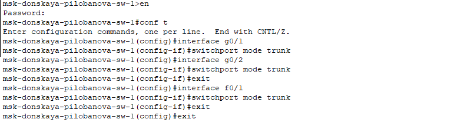

*Настройка Trunk-портов на коммутаторе msk-donskaya-pilobanova-sw-1*

Используя приведённую ниже последовательность команд по конфигурации VTP, настроила коммутатор msk-donskaya-sw-1 как VTP-сервер и прописала на нём номера и названия VLAN.

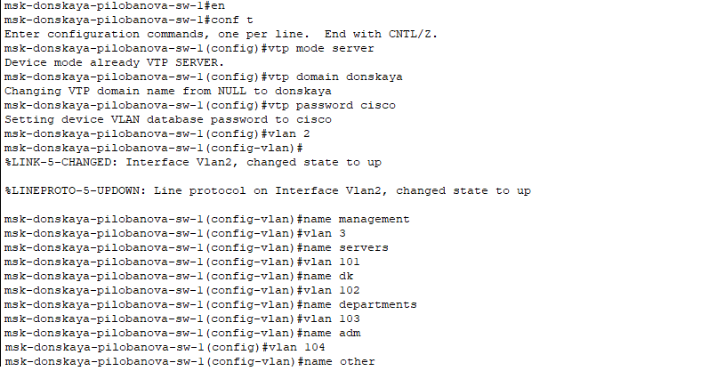

*Настройка коммутатора msk-donskaya-pilobanova-sw-1 как VTP-сервер*

Используя приведённую ниже последовательность команд по конфигурации диапазонов портов, настроила коммутаторы msk-donskaya-sw-2 — mskdonskaya-sw-4, msk-pavlovskaya-sw-1 как VTP-клиенты и на интерфейсах указала принадлежность к VLAN.

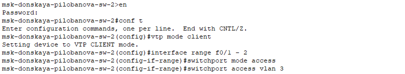

*Настройка коммутатора msk-donskaya-pilobanova-sw-2 как VTP-клиента*

казала статические IP-адреса на оконечных устройствах и серверах.

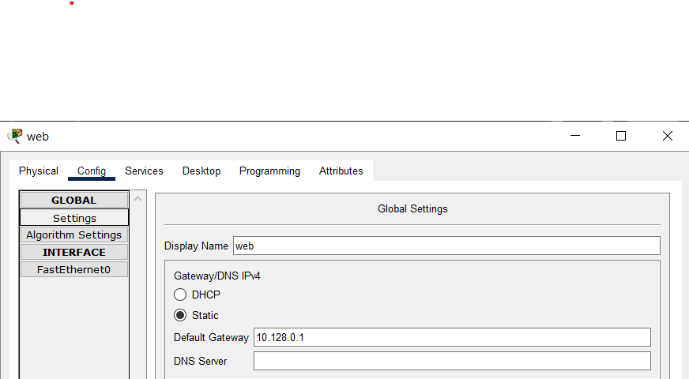

*Указание шлюза для серверов*

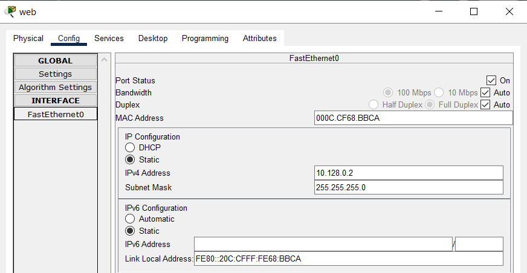

*Указание IP-адреса для сервера web*

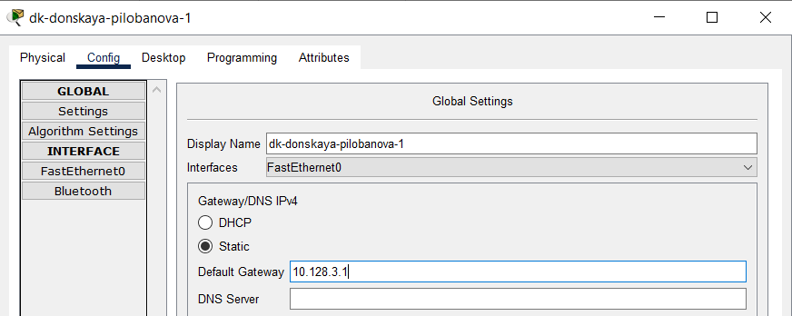

*Указание шлюза для ДК (Донская)*

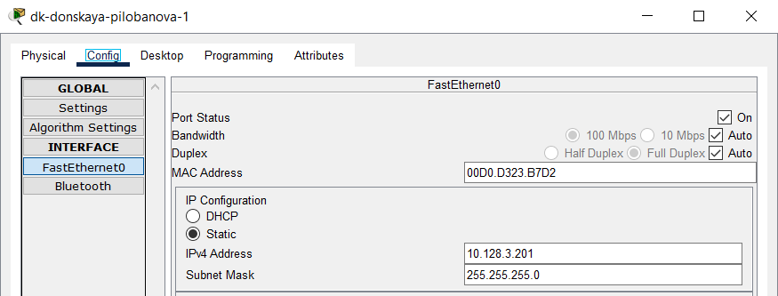

*Указание IP-адреса для ДК (Донская)*

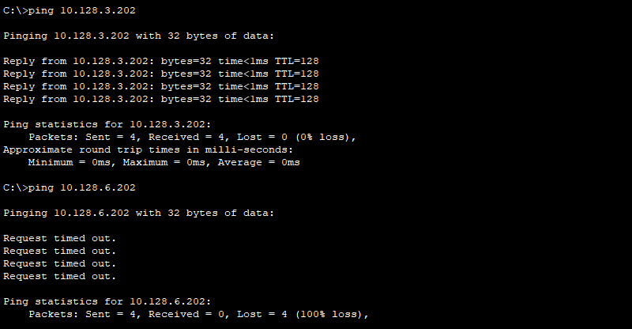

*Команда ping*

[figure not shown]

*Движение пакета к dk-donskaya-pilobanova-1 от dk-pavlovskaya-pilobanova-1*

[figure not shown]

*Движение пакета к dk-donskaya-pilobanova-1 от other-pavlovskaya-pilobanova-1*

# Вывод

Я получила основные навыки по настройке VLAN на коммутаторах сети.